# R Notebook

```r
library(readr)
```

# Limpieza de datos

```r
DF <- read_csv("Datos diversos.csv")
```

```r
summary(DF)
```

```r
library(dplyr)
```

```r
names(DF)
```

```
 [1] "Codigo"             "Apellido"
 [3] "Nombre"             "Sección"
 [5] "Ciclo"              "Edad"
 [7] "Estatura"           "Peso"
 [9] "Signo del zodiaco"  "Sexo"
[11] "Carrera"            "Tiempo de reacción"
[13] "Juega videojuegos"  "Hace deporte"
```

```r
DF$ `Signo del zodiaco`
```

```
  [1] "Capricornio" "Piscis"      "Escorpio"
  [4] "Capricornio" "Escorpio"    "Capricornio"
  [7] "Aries"       "Sagitario"   "Sagitario"
 [10] "Escorpio"    "Piscis"      "Escorpio"
 [13] "Virgo"       "Géminis"     "Tauro"
 [16] "Aries"       "Acuario"     "Capriornio"
 [19] "Libra"       "Sagitario"   "virgo"
 [22] "Capriornio"  "Cancer"      "Geminis"
 [25] "Geminis"     "Aries"       "Acuario"
 [28] "Libra"       "Géminis"     "Libra"
 [31] "Cancer"      "Sagitario"   "Piscis"
 [34] "Sagitario"   NA            "Aries"
 [37] "Geminis"     "Acuario"     "Virgo"
 [40] "Geminis"     "Leo"         "Tauro"
 [43] "Virgo"       "Sagitario"   "Sagitario"
```

[output cut: 29 more lines]

#Renombrar datos

```r
DF %>% rename(Seccion=Sección, Signo=`Signo del zodiaco`, Tiempo = `Tiempo de reacción`, Videojuegos=`Juega videojuegos`, Deporte=`Hace deporte`) -> DFN
```

¿Donde están los valores faltantes? : is.na ¿Cuántos son?: sum(is.na)

```r
sum(is.na(DFN))
```

```
[1] 40
```

```r
table(is.na(DFN))
```

```
FALSE  TRUE
 1808    40
```

```r
!complete.cases(DFN)
```

```r
table(!complete.cases(DFN))
#111 son completos
```

#Que hacemos con los datos restantes o los registros incompletos? +Eliminamos los registros con datos incompletos +Aprendemos a vivir con los datos incompletos +Podríamos intentar obtener los datos valtantes

Yo trataré de vivir con los datos faltantes

```r
names(DFN)
```

```
 [1] "Codigo"      "Apellido"    "Nombre"      "Seccion"
 [5] "Ciclo"       "Edad"        "Estatura"    "Peso"
 [9] "Signo"       "Sexo"        "Carrera"     "Tiempo"
[13] "Videojuegos" "Deporte"
```

```r
DFN %>%filter(Tiempo<200)
```

| Codigo | Apellido | Nombre | Seccion | Ciclo | Edad | Estatura | Peso | Signo | Sexo | Carrera | Tiempo | Videojuegos | Deporte |
| --- | --- | --- | --- | --- | --- | --- | --- | --- | --- | --- | --- | --- | --- |
| 201710101 | Arias Schreiber Gonzalez | Ian | 5 | 7 | 20 | 173 | 62 | Piscis | M | Ciencias de la computación | 172.000 | Si | No |
| 201910123 | Chirinos Palacios | Ignacio | NA | 3 | 18 | 174 | 64 | NA | M | Ing. Electronica | 0.187 | Si | Si |
| 201710126 | Chipana Menacho | Nicolás Alejandro | 5 | 7 | 20 | 171 | 68 | Acuario | M | Ciencias de la computación | 199.000 | Si | No |

#Chequeo de sensatez Todos los códigos son distintos

```r
length(DFN$Codigo) == length(unique(DFN$Codigo))
```

```
[1] FALSE
```

```r
length(DFN$Codigo)
```

```
[1] 132
```

```r
length(unique(DFN$Codigo))
```

```
[1] 125
```

¿Códigos repetidos? ¿Códigos faltantes?

```r
sum(is.na(DFN$Codigo))
```

```
[1] 5
```

```r
unique(DFN$Codigo)
```

```
  [1]  201610403  201810679         NA  201810439  201910052
  [6]  201910205  201810699  201910100  201910061  201810666
 [11]  201910031  201910042  201910320  201910250  201910267
 [16]  201910260  201910275  201910399  201910122  201910146
 [21]  201510013  201810580  201810381  201620035  201810511
 [26]  201910141  201810119  201810291  201810391  201920162
 [31]  201910213  201810587  201710101  201710191  201910123
 [36]  201910412  201910184  201710126  201910113  201710521
 [41]  201910176  201910231  201910270  201910342  201910252
 [46]  201910212  201810067  201910227  201910431  201910438
 [51]  201810179  201810109  201810358  201910244  201910054
 [56]  201910277  201810592  201910345  201910040  201910030
 [61]  201910032  201610275  201810389  201620073  201910242
 [66]  201910335  201720107  201910247  201910301  201820133
 [71]  201810115  201910263  201910020  201710384 2001810033
 [76]  201910369  201810083  201810518  201910314  201910517
 [81]  201810161  201910218  201810487  201910310  201910216
 [86]  201820104  201910249  201910148  201910179  201820147
 [91]  201810714  201820102  201910201  201910124  201810713
 [96]  201810438  201820127  201910083  201910253  201910259
[101]  201910128  201810118  201810098  201910229  201910041
[106]  201910329  201910001  201910325  201720108  201910293
[111]  201910226  201710344  201910336  201820076  201910059
[116]  201920069  201710591  201910019  201820100  201820033
[121]  201910232  201910007  201820046  201910209  201810373
```

```r
DFN$Codigo
```

```
  [1]  201610403  201810679         NA  201810439  201910052
  [6]  201910205  201810699  201910100  201910061  201810666
 [11]  201910031  201910042  201910320  201910250  201910267
 [16]  201910260  201910275  201910399  201910122  201910146
 [21]  201510013  201810580  201810381  201620035  201810511
 [26]  201910141  201810119  201810291  201810391  201920162
 [31]  201910213  201810587  201710101  201710191  201910123
 [36]  201910412  201910184  201710126  201910113  201710521
 [41]         NA         NA  201910176  201910231  201910270
 [46]  201910342  201910252  201910212  201810067  201910227
 [51]  201910431  201910438  201810179  201810109  201810358
 [56]  201910244  201910054  201910277  201810592  201910345
 [61]  201910040  201910030  201910032  201610275  201810389
 [66]  201620073  201910242  201910335  201720107         NA
 [71]  201910247  201910301  201820133  201810115  201910263
 [76]  201910020  201710384 2001810033  201910369  201810083
 [81]  201810518  201910314  201910517  201810161  201910218
 [86]  201810487  201910310  201910216  201820104  201910249
 [91]  201910148  201910179  201820147  201810714  201820102
 [96]  201910201  201910124         NA  201810713  201810438
[101]  201910176  201820127  201910083  201910253  201910259
[106]  201910128  201810118  201810098  201910229  201910041
[111]  201910329  201810679  201910113  201910001  201910325
[116]  201720108  201910293  201910226  201710344  201910336
[121]  201820076  201910059  201920069  201710591  201910019
[126]  201820100  201820033  201910232  201910007  201820046
[131]  201910209  201810373
```

Hay un error claro en el registro 78 (tiene 10 dígitos), que probablemente podríamos corregir si quitamos el 0 extra en el año.

```r
Cod <-DFN$Codigo
```

```r
sort(Cod)
```

Sort “bota” los NA

Diff toma diferencias de elementos consecutivos si es 0, significa q el consecutivo es igual al anterior

```r
diff(sort(Cod))
```

```
  [1]     100262        128       9632         38      90028
  [6]         25         65        153         40        137
 [11]         70       9516          1      89959         16
 [16]         15         11          6          3          1
 [21]         42         18        112         67         15
 [26]          8          8          2         47          1
 [31]         48         24          7         62          7
 [36]          5         74         13          0         20
 [41]         14          1       9319         13         30
 [46]         24          2          2         23          6
 [51]         14      89854          6         12          1
 [56]         10          1          1          8          1
 [61]          1         10          2          5          2
 [66]         22         17         13          0          9
 [71]          1          1          4         13          5
 [76]          2         28          0          3          5
 [81]         17          4          4          3          1
 [86]          3          2          8          1          2
 [91]          2          1         10          2          3
 [96]          2          1          2          1          6
[101]          1          3          4          3          5
[106]          2         16          8          9          4
[111]          6          5          4          6          1
[116]          6          3         24         30         13
[121]         19          7         79       9552         93
[126] 1799889871
```

```r
duplicated(DFN$Codigo)
```

```
  [1] FALSE FALSE FALSE FALSE FALSE FALSE FALSE FALSE FALSE
 [10] FALSE FALSE FALSE FALSE FALSE FALSE FALSE FALSE FALSE
 [19] FALSE FALSE FALSE FALSE FALSE FALSE FALSE FALSE FALSE
 [28] FALSE FALSE FALSE FALSE FALSE FALSE FALSE FALSE FALSE
 [37] FALSE FALSE FALSE FALSE  TRUE  TRUE FALSE FALSE FALSE
 [46] FALSE FALSE FALSE FALSE FALSE FALSE FALSE FALSE FALSE
 [55] FALSE FALSE FALSE FALSE FALSE FALSE FALSE FALSE FALSE
 [64] FALSE FALSE FALSE FALSE FALSE FALSE  TRUE FALSE FALSE
 [73] FALSE FALSE FALSE FALSE FALSE FALSE FALSE FALSE FALSE
 [82] FALSE FALSE FALSE FALSE FALSE FALSE FALSE FALSE FALSE
 [91] FALSE FALSE FALSE FALSE FALSE FALSE FALSE  TRUE FALSE
[100] FALSE  TRUE FALSE FALSE FALSE FALSE FALSE FALSE FALSE
[109] FALSE FALSE FALSE  TRUE  TRUE FALSE FALSE FALSE FALSE
[118] FALSE FALSE FALSE FALSE FALSE FALSE FALSE FALSE FALSE
[127] FALSE FALSE FALSE FALSE FALSE FALSE
```

```r
DFN[duplicated(DFN$Codigo),]
```

| Codigo | Apellido | Nombre | Seccion | Ciclo | Edad | Estatura | Peso | Signo | Sexo | Carrera | Tiempo | Videojuegos | Deporte |
| --- | --- | --- | --- | --- | --- | --- | --- | --- | --- | --- | --- | --- | --- |
| NA | Quineche | Luis | NA | NA | 39 | 165 | 72 | Leo | M | NA | 312 | No | No |
| NA | Gallo | Dante Jim Randal | NA | NA | 23 | 166 | 73 | Tauro | M | Ing. Mecatrónica | 292 | No | No |
| NA | Renom | José Miguel | NA | NA | 50 | 180 | 110 | Aries | M | NA | 425 | Si | No |
| NA | Molina | Brígida | NA | NA | NA | 170 | 63 | Acuario | F | NA | 347 | Si | No |
| 201910176 | Garcia Motta | Brayan | 5 | 3 | 18 | 165 | 75 | Virgo | M | Ing. Civil | 333 | Sí | Sí |
| 201810679 | Marchán Ramírez | Adriana | 3 | 5 | 19 | 162 | 46 | Piscis | F | Ingeniería Ambiental | 247 | No | No |
| 201910113 | Castro Zegarra | Juan Carlos | 3 | 3 | 18 | 170 | 70 | Virgo | M | Ing Ambiental | 250 | Si | Si |

```r
names(DFN)
```

```r
table(DFN$Seccion)
```

```
 1  2  3  4  5  6
31 26 32  8 22  5
```

```r
all(is.na(DFN$Seccion))
```

```
[1] FALSE
```

any es verdadero si al menos una d la lista es verdadera, all es solo si todos los elementos lo son

```r
summary(DFN$Estatura)
```

Podemos concluir que hay algunos errores en las estaturas

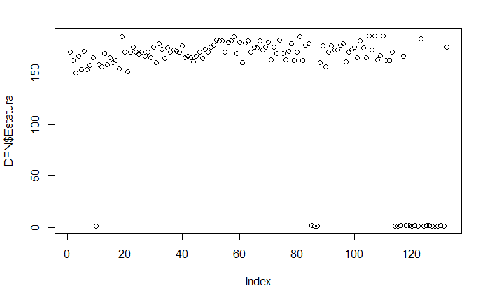

```r
plot(DFN$Estatura)
```

Las que están abajo claramente son errores

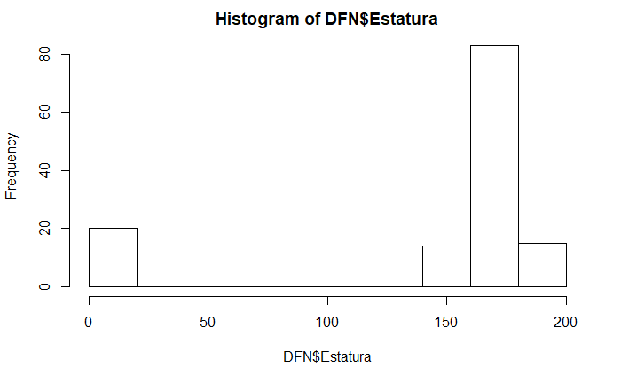

```r
hist(DFN$Estatura)
```

Vamos a resolver el problema de errores en la estatura En este caso, optaremos por colocar NA en los datos faltantes

```r
DFN$Estatura[DFN$Estatura<=100]<-NA
```

```r
summary(DFN$Estatura)
```

[output not shown]

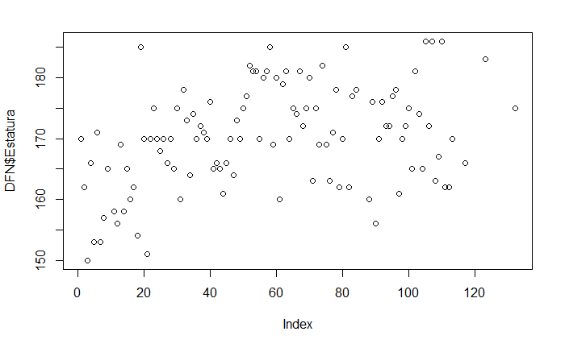

```r
plot(DFN$Estatura)
```

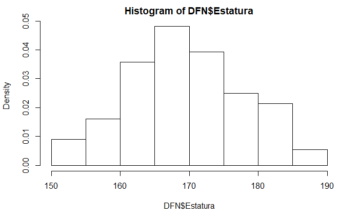

```r
hist(DFN$Estatura, prob=TRUE)
```

¿Cómo calculamos la moda?

```r
table(DFN$Estatura)
```

```
150 151 153 154 156 157 158 160 161 162 163 164
  1   1   2   1   2   1   2   4   2   6   3   2
165 166 167 168 169 170 171 172 173 174 175 176
  7   5   1   1   4  16   3   6   2   3   8   3
177 178 179 180 181 182 183 185 186
  3   4   1   3   6   2   1   3   3
```

```r
which.max(table(DFN$Estatura))
```

```
170
 18
```

```r
table(DFN$Estatura)[table(DFN$Estatura) == max(table(DFN$Estatura))]
```

```
170
 16
```

na.rm = TRUE, elimina los NA para calcular el mean, igual a la hora de la desviación estándar

```r
mean(DFN$Estatura, na.rm = TRUE)
```

```
[1] 170.1964
```

```r
sd(DFN$Estatura, na.rm = TRUE)
```

```
[1] 8.322161
```

```r
mean(DF$Estatura, na.rm = TRUE) -> xbarra
sd(DFN$Estatura, na.rm = TRUE) -> s
```

Se observa qué estaturas están a “una” desviación estándar por arriba o debajo del promedio

```r
(mean(DFN$Estatura, na.rm = TRUE)
 - sd(DFN$Estatura, na.rm = TRUE) <= DFN$Estatura) & (DFN$Estatura <= mean(DFN$Estatura, na.rm = TRUE)
 + sd(DFN$Estatura, na.rm = TRUE))
```

```
  [1]  TRUE  TRUE FALSE  TRUE FALSE  TRUE FALSE
  [8] FALSE  TRUE    NA FALSE FALSE  TRUE FALSE
 [15]  TRUE FALSE  TRUE FALSE FALSE  TRUE FALSE
 [22]  TRUE  TRUE  TRUE  TRUE  TRUE  TRUE  TRUE
 [29]  TRUE  TRUE FALSE  TRUE  TRUE  TRUE  TRUE
 [36]  TRUE  TRUE  TRUE  TRUE  TRUE  TRUE  TRUE
 [43]  TRUE FALSE  TRUE  TRUE  TRUE  TRUE  TRUE
 [50]  TRUE  TRUE FALSE FALSE FALSE  TRUE FALSE
 [57] FALSE FALSE  TRUE FALSE FALSE FALSE FALSE
 [64]  TRUE  TRUE  TRUE FALSE  TRUE  TRUE FALSE
 [71]  TRUE  TRUE  TRUE FALSE  TRUE  TRUE  TRUE
 [78]  TRUE  TRUE  TRUE FALSE  TRUE  TRUE  TRUE
 [85]    NA    NA    NA FALSE  TRUE FALSE  TRUE
 [92]  TRUE  TRUE  TRUE  TRUE  TRUE FALSE  TRUE
 [99]  TRUE  TRUE  TRUE FALSE  TRUE  TRUE FALSE
[106]  TRUE FALSE  TRUE  TRUE FALSE  TRUE  TRUE
[113]  TRUE    NA    NA    NA  TRUE    NA    NA
[120]    NA    NA    NA FALSE    NA    NA    NA
[127]    NA    NA    NA    NA    NA  TRUE
```

```r
sum((mean(DFN$Estatura, na.rm = TRUE)
 - sd(DFN$Estatura, na.rm = TRUE) <= DFN$Estatura) & (DFN$Estatura <= mean(DFN$Estatura, na.rm = TRUE)
 + sd(DFN$Estatura, na.rm = TRUE)), na.rm = TRUE)
```

```
[1] 77
```

```r
sum((mean(DFN$Estatura, na.rm = TRUE)
 - sd(DFN$Estatura, na.rm = TRUE) <= DFN$Estatura) & (DFN$Estatura <= mean(DFN$Estatura, na.rm = TRUE)
 + sd(DFN$Estatura, na.rm = TRUE)), na.rm = TRUE)/(length(DFN$Estatura) - sum(is.na(DFN$Estatura)))
```

```
[1] 0.6875
```

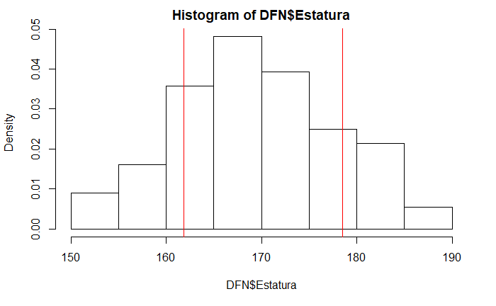

```r
hist(DFN$Estatura, prob=TRUE)
abline(v=c((mean(DFN$Estatura, na.rm = TRUE) - sd(DFN$Estatura, na.rm = TRUE)), (mean(DFN$Estatura, na.rm = TRUE) + sd(DFN$Estatura, na.rm = TRUE))),col="red")
```

```r
altos <- subset(DFN, DFN$Estatura > 180)
```

```r
summary(DF$Tiempo)
```

```r
hist(DF$Tiempo)
```

```r
DF$Tiempo<200
```

```r
DF[DF$Tiempo<200,]
```

```r
DF %>% filter(Tiempo<200)
```

```r
boxplot(DF$Tiempo)
```

```r
DF[DF$Tiempo<1,]
```

```r
DF[DF$Codigo==201910123,]
```

```r
DF%>% filter(Codigo==201910123) %>% mutate(Tiempo = NA)
```

```r
DFN[DFN$Codigo==201910123,"Tiempo"]
```

```r
DFN[DFN$Codigo==201910123,]$Tiempo <- NA
```

# Descripción de datos

```r
smoothScatter(DF$Estatura, DF$Peso)
```